# HW5

# Question 1b

Run a simple regression to try and predict DWinNxt with DemWin. Observe the coe???cient on DemWin. Do you think it gives an unbiased estiamte of the incumbency e???ect. Why or why not?

```r
model <- lm(DWinNxt ~ DemWin, data)
summary(model)
```

```
##
## Call:
## lm(formula = DWinNxt ~ DemWin, data = data)
##
## Residuals:
##      Min       1Q   Median       3Q      Max
## -0.92374 -0.11397  0.07626  0.07626  0.88603
##
## Coefficients:
##             Estimate Std. Error t value Pr(>|t|)
## (Intercept) 0.113966   0.004292   26.55   <2e-16 ***
## DemWin      0.809775   0.005736  141.18   <2e-16 ***
## ---
## Signif. codes:  0 '***' 0.001 '**' 0.01 '*' 0.05 '.' 0.1 ' ' 1
##
## Residual standard error: 0.2896 on 10348 degrees of freedom
##   (6618 observations deleted due to missingness)
## Multiple R-squared:  0.6583, Adjusted R-squared:  0.6582
## F-statistic: 1.993e+04 on 1 and 10348 DF,  p-value: < 2.2e-16
```

The coefficient raises the chances of the incumbent to close to 90%. I think it doesn’t give an unbiased estimate of the model because there are other factors that cause the incumbent to be reelected- the same factors that caused him to get elected.

# Question 1c

Now consider the various potential controls I mentioned above. Classify each one as a confounding, variance reducing, unrelated, or bad control. Introduce some/all of these variables to your regression and see what happens to the coe???cient on DemWin.

- ForgnPct- confounding
- GovWkPct- unrelated
- BlackPct- confounding
- UrbanPct- confounding
- DWinPrv - confounding
- YearElec- unrelated
- CDNum - unrelated

```r
model <- lm(DWinNxt ~ DemWin + ForgnPct + BlackPct + UrbanPct + DWinPrv, data)
summary(model)
```

```
##
## Call:
## lm(formula = DWinNxt ~ DemWin + ForgnPct + BlackPct + UrbanPct +
##     DWinPrv, data = data)
##
## Residuals:
##      Min       1Q   Median       3Q      Max
## -1.02971 -0.08935  0.04290  0.08886  0.93193
##
## Coefficients:
##              Estimate Std. Error t value Pr(>|t|)
## (Intercept) 0.0639093  0.0093929   6.804 1.09e-11 ***
## DemWin      0.6928097  0.0113121  61.245  < 2e-16 ***
## ForgnPct    0.0020565  0.0005939   3.463 0.000537 ***
## BlackPct    0.0017476  0.0002447   7.143 9.90e-13 ***
## UrbanPct    0.0001783  0.0001433   1.245 0.213312
## DWinPrv     0.1200971  0.0113466  10.584  < 2e-16 ***
## ---
## Signif. codes:  0 '***' 0.001 '**' 0.01 '*' 0.05 '.' 0.1 ' ' 1
##
## Residual standard error: 0.2859 on 8263 degrees of freedom
##   (8699 observations deleted due to missingness)
## Multiple R-squared:  0.6659, Adjusted R-squared:  0.6657
## F-statistic:  3294 on 5 and 8263 DF,  p-value: < 2.2e-16
```

# Question 1d

Give an additional example of a bad control variable in this setting. It does not have to be one that it is present in the dataset. Whether a democrat won the next year in the election.

# Question 1e

```r
dataWindow <- data %>% filter(DifDPct > -15 & DifDPct < 15 & ! is.na(DifDPct))
model <- lm(DWinNxt ~ DemWin*poly(DifDPct,3, raw = TRUE) + ForgnPct + BlackPct + UrbanPct + DWinPrv, dataWindow)
summary(model)
```

```
##
## Call:
## lm(formula = DWinNxt ~ DemWin * poly(DifDPct, 3, raw = TRUE) +
##     ForgnPct + BlackPct + UrbanPct + DWinPrv, data = dataWindow)
##
## Residuals:
##      Min       1Q   Median       3Q      Max
## -1.01212 -0.19491 -0.09505  0.22267  0.93366
##
## Coefficients:
##                                        Estimate Std. Error t value
## (Intercept)                           1.601e-01  5.238e-02   3.056
## DemWin                                4.652e-01  6.645e-02   7.001
## poly(DifDPct, 3, raw = TRUE)1         9.354e-03  2.720e-02   0.344
## poly(DifDPct, 3, raw = TRUE)2         1.049e-04  4.199e-03   0.025
## poly(DifDPct, 3, raw = TRUE)3         5.320e-07  1.836e-04   0.003
## ForgnPct                              8.429e-03  1.997e-03   4.220
## BlackPct                              3.072e-03  1.165e-03   2.637
## UrbanPct                              3.682e-04  4.010e-04   0.918
## DWinPrv                               2.696e-02  1.943e-02   1.388
## DemWin:poly(DifDPct, 3, raw = TRUE)1 -2.212e-02  3.826e-02  -0.578
## DemWin:poly(DifDPct, 3, raw = TRUE)2  4.541e-03  5.974e-03   0.760
## DemWin:poly(DifDPct, 3, raw = TRUE)3 -2.147e-04  2.629e-04  -0.816
##                                      Pr(>|t|)
## (Intercept)                           0.00227 **
## DemWin                               3.38e-12 ***
## poly(DifDPct, 3, raw = TRUE)1         0.73099
## poly(DifDPct, 3, raw = TRUE)2         0.98007
## poly(DifDPct, 3, raw = TRUE)3         0.99769
## ForgnPct                             2.54e-05 ***
## BlackPct                              0.00842 **
## UrbanPct                              0.35863
## DWinPrv                               0.16529
## DemWin:poly(DifDPct, 3, raw = TRUE)1  0.56328
## DemWin:poly(DifDPct, 3, raw = TRUE)2  0.44728
## DemWin:poly(DifDPct, 3, raw = TRUE)3  0.41437
## ---
## Signif. codes:  0 '***' 0.001 '**' 0.01 '*' 0.05 '.' 0.1 ' ' 1
##
## Residual standard error: 0.3889 on 2142 degrees of freedom
##   (1218 observations deleted due to missingness)
## Multiple R-squared:  0.3957, Adjusted R-squared:  0.3926
## F-statistic: 127.5 on 11 and 2142 DF,  p-value: < 2.2e-16
```

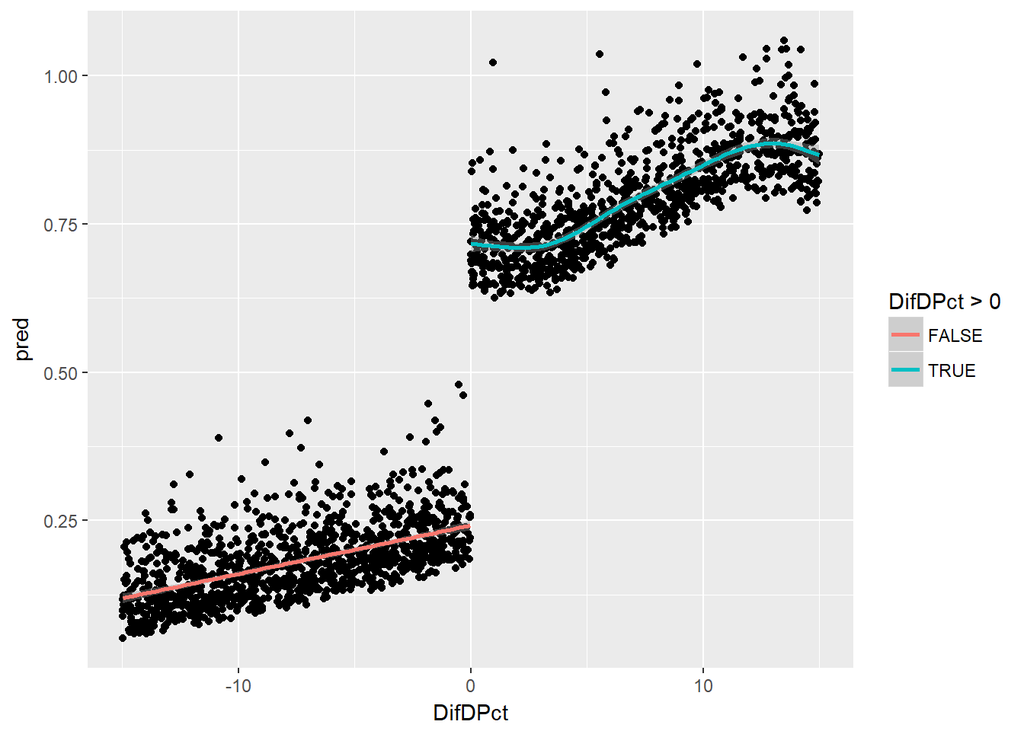

```r
dataWindow$pred <- predict(model, dataWindow)
dataWindow %>% ggplot(aes(x = DifDPct, y = pred)) +
  geom_point() +
  geom_smooth(aes(color = DifDPct > 0))
```

The coefficient on DemWin is smaller than in part b and c. Some of the bias is removed, but there is still an incumbency effect.

# Question 1f

Use the functions RDestimate and plot to do a faster regression discontinuity anlaysis.

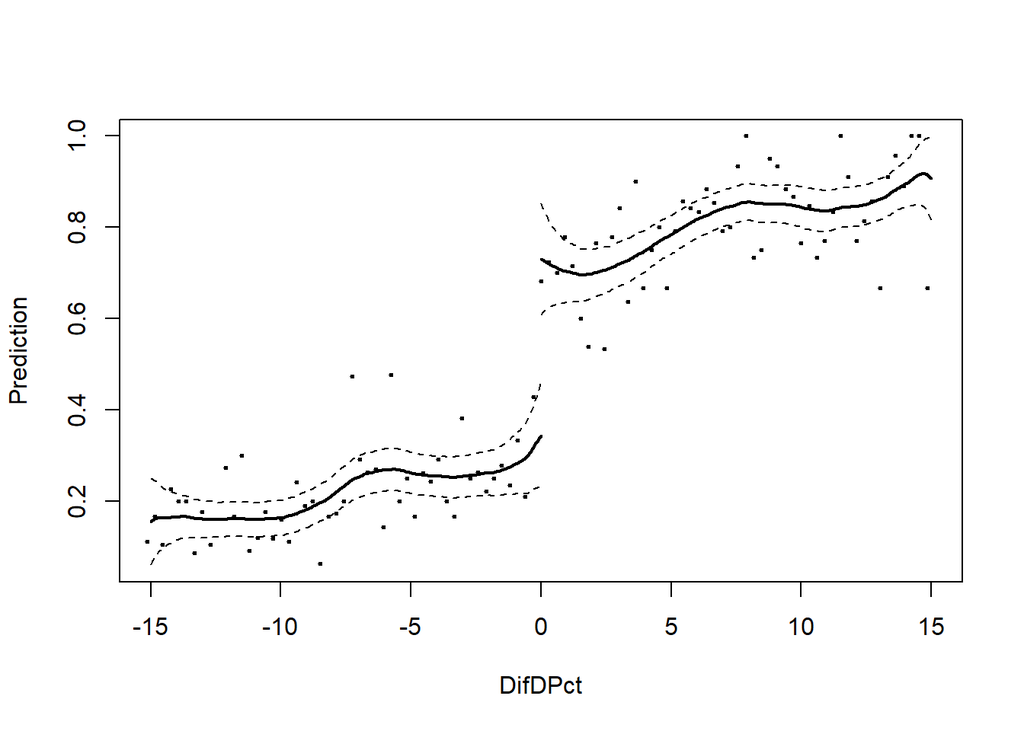

```r
est <- RDestimate(DWinNxt ~ DifDPct, dataWindow)
plot(est)
title(xlab = "DifDPct", ylab = "Prediction")
```

```r
summary(est)
```

```
##
## Call:
## RDestimate(formula = DWinNxt ~ DifDPct, data = dataWindow)
##
## Type:
## sharp
##
## Estimates:
##            Bandwidth  Observations  Estimate  Std. Error  z value
## LATE       2.691      428           0.4960    0.09121     5.438
## Half-BW    1.346      213           0.4170    0.13079     3.188
## Double-BW  5.383      924           0.4804    0.06427     7.475
##            Pr(>|z|)
## LATE       5.380e-08  ***
## Half-BW    1.431e-03  **
## Double-BW  7.736e-14  ***
## ---
## Signif. codes:  0 '***' 0.001 '**' 0.01 '*' 0.05 '.' 0.1 ' ' 1
##
## F-statistics:
##            F      Num. DoF  Denom. DoF  p
## LATE       45.17  3         424         0.000e+00
## Half-BW    22.84  3         209         1.571e-12
## Double-BW  86.76  3         920         0.000e+00
```

There is a similar coefficient to part e.